# Exclusions

Alex Holcombe

2/26/2018

Load data and estimates

Fix the variable names if not done

Add the parameter estimates to the tibble

Merge operation lost it targetSP==NA in data? That’s the rows reporting stream on opposite side. Eventually, use those to evaluate swaps. I don’t know what happened to it, because it’s created in exclusions.Rmd, which on line 67 creates the thing merged with estimates that is saved.

```
##
##    5    6    7    8    9   10   11   12  NaN
## 3673 3573 3488 3531 3644 3604 3675 3612 5760
```

One-target:

BE has e=.47 on left, .62 on right BJ is just near chance and fails likelihood ratio test for 1-target, like did for 2-targets. BO did badly for canonical on left, but passed lr test. CF did badly for inverted on left, but passed lr test. CL did pretty badly but got lucky, passed. AP flunked one of the lr tests which is good because flunked some in two-target too. So, lr test seems to be working well enough.

BG, BJ, and AP have sigma near 4, clear outliers.

## Exclusions based on two-target conditions

Notes from histsWithFitsTwoTarget.Rmd: AP, especially BJ does flunk likelihood test! CY passes but data not horrifyingly bad. Exclude by likelihood-ratio test. Participant AI, BB suspicion of attending to one side from twoTargets condition.

Exclude by likelihood ratio test and efficacy.

For each subject, calculate how many two-target streams they failed. If 3 or 4 of 4, exclude (didn’t think to mention 1-target condition in prereg).

Also check whether average efficacy is below 10% in both streams in either the upright or the reversed orientation.

```r
twoTarget<- dg %>% filter(targetSide=="both")

#first, collapse over trials
#https://stackoverflow.com/questions/51978519/summarise-numeric-columns-return-last-value-of-non-numeric
tw<- twoTarget %>% group_by(subject,stream,orientation) %>% select(-targetStreamOrientations,-letterSeq) %>% #can't include list columns
  summarise_all( function(x){ if(is.numeric(x)){ return(mean(x)) } else{ nth(x,-1) } })

#for each subject, count pLRtest instances >.05 and efficay <.1
B<-tw %>% ungroup %>% group_by(subject) %>% summarise(LRtestFails = sum(pLRtest>.05), effFails = sum(efficacy<.1))
#B %>% print(n=Inf)
LRtestLosers <- B %>% filter(LRtestFails>=3)
LRtestLosers<- unique(LRtestLosers$subject)
# efficacy is below 10% in both streams in either the upright or the reversed orientation.
# To calculate that, need to group by subject and orientation
C<-tw %>% ungroup %>% group_by(subject,orientation) %>% summarise(bothEffsFailed = sum(efficacy<.1)==2)
#Find which subjects, if any, has a bothEffsFailed==TRUE
lowEff<- C %>% filter(bothEffsFailed==TRUE)
lowEffLosers <- unique(lowEff$subject)
```

## Exclusions based on one-target conditions

Will also exclude if difference in efficacy left-right exceeds?

```r
#Calculate exclusions based on one-target performance
oneTarget<- dg %>% filter(targetSide!="both")
one<- oneTarget %>% group_by(subject,targetSide,orientation) %>%
  select(-targetStreamOrientations,-letterSeq) %>% #can't include list columns
  select(-trial,-targetSP,-respSP,-respOrder) %>% #clear detritus so easier to see
  summarise_all( function(x){ if(is.numeric(x)){ return(mean(x)) } else{ nth(x,-1) } })

#Look at the difference in efficacy between the left and the right
effDiff <- function(df) {
  #dgi<<-df
  #STOP
  effLeft<- (df %>% filter(targetSide=="left"))$efficacy
  effRight<- (df %>% filter(targetSide=="right"))$efficacy
  df$effDiff<- effLeft - effRight
  df$effLeft <- effLeft; df$effRight <- effRight

  df$efficacy<- mean(c(effLeft,effRight))
  df$effDiff<- effLeft - effRight

  failedBothLR <- ((df %>% filter(targetSide=="left"))$pLRtest >= .05) &
    ((df %>% filter(targetSide=="right"))$pLRtest >= .05)
  df$failedBothLR <- failedBothLR

  return(df[1,]) #return first row, so it does get collapsed
}

oneDiff<- one %>% group_by(subject,orientation) %>% do( effDiff(.) )
oneDiff %>% select(subject,targetSide,orientation,efficacy,effDiff,pLRtest,failedBothLR)
```

```
## # A tibble: 160 x 7
## # Groups:   subject, orientation [160]
##    subject targetSide orientation efficacy  effDiff  pLRtest failedBothLR
##    <chr>   <chr>      <chr>          <dbl>    <dbl>    <dbl> <lgl>
##  1 AA      left       Canonical      0.868 -0.0103  2.89e-11 FALSE
##  2 AA      left       Inverted       0.789 -0.00957 6.75e- 8 FALSE
##  3 AB      left       Canonical      0.932 -0.137   1.79e-12 FALSE
##  4 AB      left       Inverted       0.827  0.0719  6.78e-11 FALSE
##  5 AC      left       Canonical      0.888  0.0456  2.70e- 9 FALSE
##  6 AC      left       Inverted       0.770  0.0797  6.69e-11 FALSE
##  7 AD      left       Canonical      0.726  0.547   1.73e- 9 FALSE
##  8 AD      left       Inverted       0.810 -0.127   2.61e- 9 FALSE
##  9 AE      left       Canonical      1      0       3.35e-18 FALSE
## 10 AE      left       Inverted       0.897  0.205   7.57e-16 FALSE
## # ... with 150 more rows
```

```r
oneTargetLosers <- oneDiff %>% filter(failedBothLR == TRUE, effDiff > .4)
oneTargetLosers<- unique(oneTargetLosers$subject)
```

Make scatterplot of efficacy for left vs. right single target

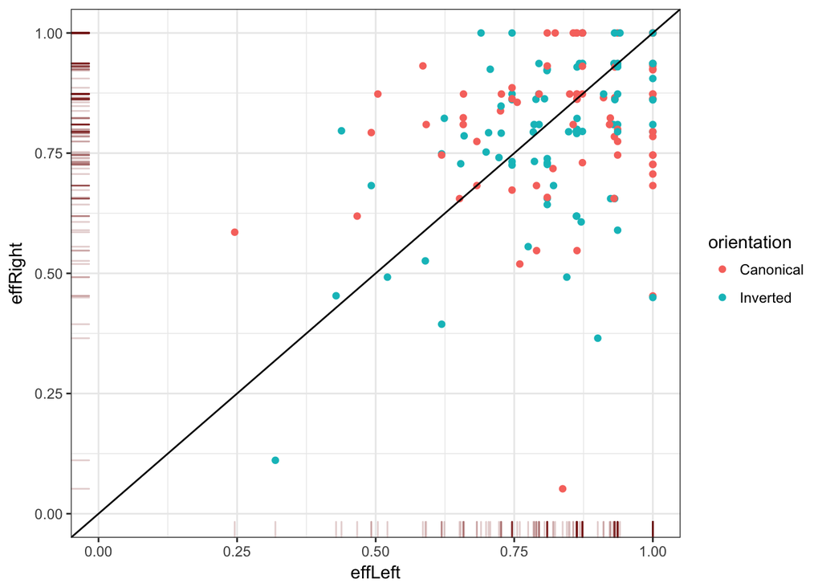

```r
#To do that, do I'd either need to unmelt (spread) but rather than do that, I programmed putting effLeft and effRight on same row into effDiff
library(ggplot2)
g<- ggplot(oneDiff, aes(x=effLeft, y=effRight, color=orientation)) + geom_point()
g<-g +  geom_abline(intercept = 0, slope = 1) + theme_bw() + xlim(0,1) + ylim(0,1)
g +    geom_rug(col=rgb(.5,0,0,alpha=.2))
```

I now have LRtestLosers, lowEffLosers, and oneTargetLosers

Actually exclude the losers? Probably better if flag them so can run inferential stats both with and without them.

Next stop, inferential stats? Save data with estimates and exclude field added.